# ISLR chapter 4

Литвинцев И.С

22 августа 2018 г

## 4.6 Lab: Logistic Regression, LDA, QDA, and KNN

### 4.6.1 The Stock Market Data

Ежедневная процентная доходность фондового индекса S&P500 в период с 2001 по 2005 год.

A data frame with 1250 observations on the following 9 variables.

1. Year - The year that the observation was recorded
2. Lag1 - Percentage return for previous day
3. Lag2 - Percentage return for 2 days previous
4. Lag3 - Percentage return for 3 days previous
5. Lag4 - Percentage return for 4 days previous
6. Lag5 - Percentage return for 5 days previous
7. Volume - Volume of shares traded (number of daily shares traded in billions). Объем торгуемых акций (количество ежедневно торгуемых акций в миллиардах)
8. Today - Percentage return for today
9. Direction - A factor with levels Down and Up indicating whether the market had a positive or negative return on a given day

Рыночная доходность акций, то есть за счет роста курсовой стоимости, рассчитывается по формуле:

$$r=\frac{P_1-P_0}{P_0}\times 100\%.$$

где $P_1$ — цена продажи акции, $P_0$ — цена покупки акции.

```r
head(Smarket)
```

```
##   Year   Lag1   Lag2   Lag3   Lag4   Lag5 Volume  Today Direction
## 1 2001  0.381 -0.192 -2.624 -1.055  5.010 1.1913  0.959        Up
## 2 2001  0.959  0.381 -0.192 -2.624 -1.055 1.2965  1.032        Up
## 3 2001  1.032  0.959  0.381 -0.192 -2.624 1.4112 -0.623      Down
## 4 2001 -0.623  1.032  0.959  0.381 -0.192 1.2760  0.614        Up
## 5 2001  0.614 -0.623  1.032  0.959  0.381 1.2057  0.213        Up
## 6 2001  0.213  0.614 -0.623  1.032  0.959 1.3491  1.392        Up
```

```r
dim(Smarket)
```

```
## [1] 1250    9
```

```r
summary(Smarket)
```

```
##       Year           Lag1                Lag2
##  Min.   :2001   Min.   :-4.922000   Min.   :-4.922000
##  1st Qu.:2002   1st Qu.:-0.639500   1st Qu.:-0.639500
##  Median :2003   Median : 0.039000   Median : 0.039000
##  Mean   :2003   Mean   : 0.003834   Mean   : 0.003919
##  3rd Qu.:2004   3rd Qu.: 0.596750   3rd Qu.: 0.596750
##  Max.   :2005   Max.   : 5.733000   Max.   : 5.733000
##       Lag3                Lag4                Lag5
##  Min.   :-4.922000   Min.   :-4.922000   Min.   :-4.92200
##  1st Qu.:-0.640000   1st Qu.:-0.640000   1st Qu.:-0.64000
##  Median : 0.038500   Median : 0.038500   Median : 0.03850
##  Mean   : 0.001716   Mean   : 0.001636   Mean   : 0.00561
##  3rd Qu.: 0.596750   3rd Qu.: 0.596750   3rd Qu.: 0.59700
##  Max.   : 5.733000   Max.   : 5.733000   Max.   : 5.73300
##      Volume           Today           Direction
##  Min.   :0.3561   Min.   :-4.922000   Down:602
##  1st Qu.:1.2574   1st Qu.:-0.639500   Up  :648
##  Median :1.4229   Median : 0.038500
##  Mean   :1.4783   Mean   : 0.003138
##  3rd Qu.:1.6417   3rd Qu.: 0.596750
##  Max.   :3.1525   Max.   : 5.733000
```

The cor() function produces a matrix that contains all of the pairwise correlations among the predictors in a data set. We should to exclude a qualitative variable `Direction`.

```r
cor(Smarket[ , -9])
```

```
##              Year         Lag1         Lag2         Lag3         Lag4
## Year   1.00000000  0.029699649  0.030596422  0.033194581  0.035688718
## Lag1   0.02969965  1.000000000 -0.026294328 -0.010803402 -0.002985911
## Lag2   0.03059642 -0.026294328  1.000000000 -0.025896670 -0.010853533
## Lag3   0.03319458 -0.010803402 -0.025896670  1.000000000 -0.024051036
## Lag4   0.03568872 -0.002985911 -0.010853533 -0.024051036  1.000000000
## Lag5   0.02978799 -0.005674606 -0.003557949 -0.018808338 -0.027083641
## Volume 0.53900647  0.040909908 -0.043383215 -0.041823686 -0.048414246
## Today  0.03009523 -0.026155045 -0.010250033 -0.002447647 -0.006899527
##                Lag5      Volume        Today
## Year    0.029787995  0.53900647  0.030095229
## Lag1   -0.005674606  0.04090991 -0.026155045
## Lag2   -0.003557949 -0.04338321 -0.010250033
## Lag3   -0.018808338 -0.04182369 -0.002447647
## Lag4   -0.027083641 -0.04841425 -0.006899527
## Lag5    1.000000000 -0.02200231 -0.034860083
## Volume -0.022002315  1.00000000  0.014591823
## Today  -0.034860083  0.01459182  1.000000000
```

As one would expect, the correlations between the lag variables and today’s returns are close to zero. In other words, there appears to be little correlation between today’s returns and previous days’ returns. The only substantial correlation is between Year and Volume. By plotting the data we see that Volume is increasing over time. In other words, the average number of shares traded daily increased from 2001 to 2005

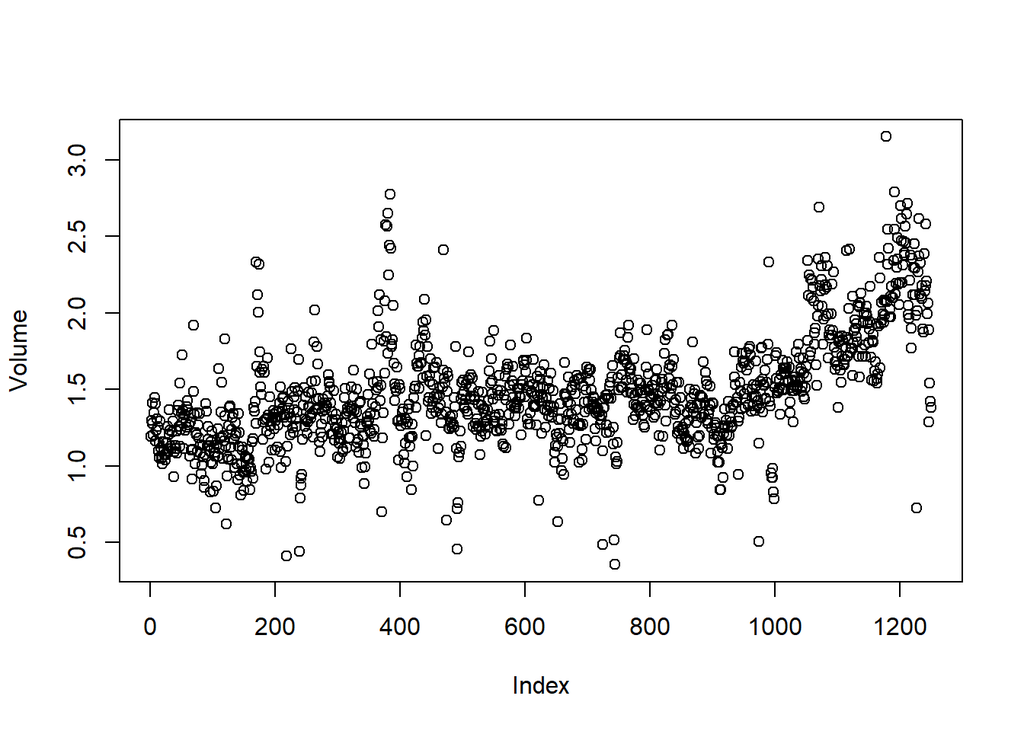

```r
attach(Smarket)
plot(Volume)
```

### 4.6.2 Logistic Regression

Next, we will fit a logistic regression model in order to predict Direction using `Lag1` through `Lag5` and `Volume`. The `glm()` function fits generalized linear models, a class of models that includes logistic regression. The syntax of the `glm()` function is similar to that of `lm()`, except that we must pass in linear model the argument `family=binomial` in order to tell R to run a logistic regression rather than some other type of generalized linear model.

```r
glm.fit <- glm(Direction ~ Lag1+Lag2+Lag3+Lag4+Lag5+Volume, data=Smarket, family=binomial)
summary(glm.fit)
```

```
##
## Call:
## glm(formula = Direction ~ Lag1 + Lag2 + Lag3 + Lag4 + Lag5 +
##     Volume, family = binomial, data = Smarket)
##
## Deviance Residuals:
##    Min      1Q  Median      3Q     Max
## -1.446  -1.203   1.065   1.145   1.326
##
## Coefficients:
##              Estimate Std. Error z value Pr(>|z|)
## (Intercept) -0.126000   0.240736  -0.523    0.601
## Lag1        -0.073074   0.050167  -1.457    0.145
## Lag2        -0.042301   0.050086  -0.845    0.398
## Lag3         0.011085   0.049939   0.222    0.824
## Lag4         0.009359   0.049974   0.187    0.851
## Lag5         0.010313   0.049511   0.208    0.835
## Volume       0.135441   0.158360   0.855    0.392
##
## (Dispersion parameter for binomial family taken to be 1)
##
##     Null deviance: 1731.2  on 1249  degrees of freedom
## Residual deviance: 1727.6  on 1243  degrees of freedom
## AIC: 1741.6
##
## Number of Fisher Scoring iterations: 3
```

The smallest p-value here is associated with Lag1. The negative coefficient for this predictor suggests that if the market had a positive return yesterday, then it is less likely to go up today. However, at a value of 0.15, the p-value is still relatively large, and so there is no clear evidence of a real association between `Lag1` and `Direction`.

We use the `coef()` function in order to access just the coefficients for this fitted model. We can also use the `summary()` function to access particular aspects of the fitted model, such as the p-values for the coefficients.

```r
coef(glm.fit)
```

```
##  (Intercept)         Lag1         Lag2         Lag3         Lag4
## -0.126000257 -0.073073746 -0.042301344  0.011085108  0.009358938
##         Lag5       Volume
##  0.010313068  0.135440659
```

```r
summary(glm.fit)$coef
```

```
##                 Estimate Std. Error    z value  Pr(>|z|)
## (Intercept) -0.126000257 0.24073574 -0.5233966 0.6006983
## Lag1        -0.073073746 0.05016739 -1.4565986 0.1452272
## Lag2        -0.042301344 0.05008605 -0.8445733 0.3983491
## Lag3         0.011085108 0.04993854  0.2219750 0.8243333
## Lag4         0.009358938 0.04997413  0.1872757 0.8514445
## Lag5         0.010313068 0.04951146  0.2082966 0.8349974
## Volume       0.135440659 0.15835970  0.8552723 0.3924004
```

```r
summary(glm.fit)$coef[,4]
```

```
## (Intercept)        Lag1        Lag2        Lag3        Lag4        Lag5
##   0.6006983   0.1452272   0.3983491   0.8243333   0.8514445   0.8349974
##      Volume
##   0.3924004
```

The `predict()` function can be used to predict the probability that the market will go up, given values of the predictors. The `type="response"` option tells R to output probabilities of the form $P(Y = 1 \;| \;X)$, as opposed to other information such as the logit. If no data set is supplied to the `predict()` function, then the probabilities are computed for the training data that was used to fit the logistic regression model. Here we have printed only the first ten probabilities. We know that these values correspond to the probability of the market going up, rather than down, because the `contrasts()` function indicates that R has created a dummy variable with a 1 for Up.

```r
glm.probs <- predict(glm.fit, type="response")
glm.probs[1:10]
```

```
##         1         2         3         4         5         6         7
## 0.5070841 0.4814679 0.4811388 0.5152224 0.5107812 0.5069565 0.4926509
##         8         9        10
## 0.5092292 0.5176135 0.4888378
```

```r
contrasts(Direction)
```

```
##      Up
## Down  0
## Up    1
```

In order to make a prediction as to whether the market will go up or down on a particular day, we must convert these predicted probabilities into class labels, Up or Down. The following two commands create a vector of class predictions based on whether the predicted probability of a market increase is greater than or less than 0.5.

```r
glm.pred <- rep("Down ", 1250)
glm.pred[glm.probs > 0.5] = "Up"
```

The first command creates a vector of 1,250 Down elements. The second line transforms to Up all of the elements for which the predicted probability of a market increase exceeds 0.5. Given these predictions, the table() function can be used to produce a confusion matrix in order to determine how many observations were correctly or incorrectly classified.

```r
table(glm.pred, Direction)
```

```
##         Direction
## glm.pred Down  Up
##    Down   145 141
##    Up     457 507
```

```r
(507 + 145)/1250
```

```
## [1] 0.5216
```

```r
mean(glm.pred == Direction)
```

```
## [1] 0.4056
```

To implement this strategy, we will first create a vector corresponding to the observations from 2001 through 2004. We will then use this vector to create a held out data set of observations from 2005.

```r
train <- (Year<2005) #boolean vector
Smarket.2005 <- Smarket[!train, ]
dim(Smarket.2005)
```

```
## [1] 252   9
```

```r
Direction.2005 <- Direction[!train]
length(Direction.2005)
```

```
## [1] 252
```

We now fit a logistic regression model using only the subset of the observations that correspond to dates before 2005, using the subset argument. We then obtain predicted probabilities of the stock market going up for each of the days in our test set—that is, for the days in 2005. (Затем мы получим прогнозируемые вероятности роста фондового рынка за каждый из дней нашего тестового набора, то есть в течение 2005 года).

```r
glm.fit <- glm(Direction ~ Lag1+Lag2+Lag3+Lag4+Lag5+Volume, data=Smarket, family=binomial, subset=train)
glm.probs <- predict(glm.fit, Smarket.2005, type="response")
```

Notice that we have trained and tested our model on two completely separate data sets: training was performed using only the dates before 2005, and testing was performed using only the dates in 2005. Finally, we compute the predictions for 2005 and compare them to the actual movements of the market over that time period.

```r
glm.pred <- rep("Down", 252)
glm.pred[glm.probs > 0.5]="Up"
table(glm.pred, Direction.2005)
```

```
##         Direction.2005
## glm.pred Down Up
##     Down   77 97
##     Up     34 44
```

```r
mean(glm.pred==Direction.2005)
```

```
## [1] 0.4801587
```

```r
mean(glm.pred!=Direction.2005)
```

```
## [1] 0.5198413
```

The results are rather disappointing: the test error rate is 52 %, which is worse than random guessing! Of course this result is not all that surprising, given that one would not generally expect to be able to use previous days’ returns to predict future market performance (Конечно, этот результат не так уж и удивителен, учитывая, что обычно не ожидается, что он сможет использовать предыдущие дни для прогнозирования будущей производительности рынка). (After all, if it were possible to do so, then the authors of this book would be rich rather than writing a statistics textbook.)

We recall that the logistic regression model had very underwhelming p-values associated with all of the predictors, and that the smallest p-value, though not very small, corresponded to `Lag1`. Perhaps by removing the variables that appear not to be helpful in predicting `Direction`, we can obtain a more effective model. After all, using predictors that have no relationship with the response tends to cause a deterioration (ухудшение) in the test error rate (поскольку такие предсказатели вызывают увеличение дисперсии без соответствующего уменьшения смещения), and so removing such predictors may in turn yield an improvement. Below we have refit the logistic regression using just `Lag1` and `Lag2`, which seemed to have the highest predictive power in the original logistic regression model.

```r
glm.fit <- glm(Direction ~ Lag1+Lag2, data=Smarket, family =binomial,
subset=train)
glm.probs <- predict(glm.fit, Smarket.2005, type = "response")
glm.pred <- rep("Down", 252)
glm.pred[glm.probs>0.5]="Up"
table(glm.pred, Direction.2005)
```

```
##         Direction.2005
## glm.pred Down  Up
##     Down   35  35
##     Up     76 106
```

```r
mean(glm.pred==Direction.2005)
```

```
## [1] 0.5595238
```

Now the results appear to be a little better: 56% of the daily movements have been correctly predicted. Стоит отметить, что в этом случае гораздо более простая стратегия прогнозирования того, что рынок будет расти каждый день, также будет правильной в 56% случаев!

Hence, in terms of overall error rate, the logistic regression method is no better than the na????ve approach. However, the confusion matrix shows that on days when logistic regression predicts an increase in the market, it has a 58% accuracy rate. This suggests a possible trading strategy of buying on days when the model predicts an increasing market, and avoiding trades on days when a decrease is predicted. Of course one would need to investigate more carefully whether this small improvement was real or just due to random chance.

Suppose that we want to predict the returns associated with particular values of `Lag1` and `Lag2`. In particular, we want to predict `Direction` on a day when `Lag1` and `Lag2` equal 1.2 and 1.1, respectively, and on a day when they equal 1.5 and ???0.8. We do this using the `predict()` function.

```r
predict(glm.fit, newdata = data.frame(Lag1=c(1.2, 1.5), Lag2=c(1.1, -0.8)), type="response")
```

```
##         1         2
## 0.4791462 0.4960939
```

### 4.6.3 Linear Discriminant Analysis

Now we will perform LDA on the Smarket data. In R, we fit an LDA model using the `lda()` function, which is part of the MASS library. Notice that the syntax for the `lda()` function is identical to that of `lm()`, and to that of `glm()` except for the absence of the family option. We fit the model using only the observations before 2005.

```r
library(MASS)
lda.fit <- lda(Direction ~ Lag1+Lag2, data=Smarket, subset=train)
lda.fit
```

```
## Call:
## lda(Direction ~ Lag1 + Lag2, data = Smarket, subset = train)
##
## Prior probabilities of groups:
##     Down       Up
## 0.491984 0.508016
##
## Group means:
##             Lag1        Lag2
## Down  0.04279022  0.03389409
## Up   -0.03954635 -0.03132544
##
## Coefficients of linear discriminants:
##             LD1
## Lag1 -0.6420190
## Lag2 -0.5135293
```

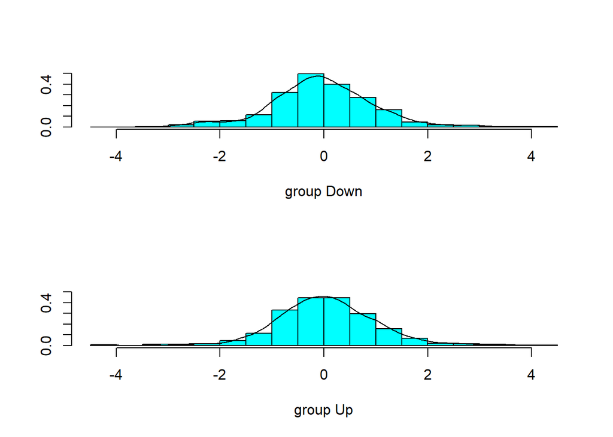

```r
plot(lda.fit, type="both")
```

Пытаюсь понять что такое `scaling` в выдвче `lda()`. Вручную посчитал коэффициенты при икс в формуле (4.19). Почему-то они отличаются, но 100% коррелируют. Видимо различие кроется в этих словах о параметре `scaling` из справки по `?lda`. scaling - матрица, которая преобразует наблюдения в дискриминантные функции, нормированные так, что внутри группы ковариационная матрица является сферической.

```r
sigma <- matrix(c(cov(Lag1, Lag1), cov(Lag1, Lag2), cov(Lag1, Lag2), cov(Lag2, Lag2)), nrow=2)

invs <- solve(sigma)

mu1 <- lda.fit$means[1, ]
mu2 <- lda.fit$means[2, ]

myscaling <-invs%*%(mu2-mu1)
lda.fit$means
```

```
##             Lag1        Lag2
## Down  0.04279022  0.03389409
## Up   -0.03954635 -0.03132544
```

```r
cor(myscaling, lda.fit$scaling)
```

```
##      LD1
## [1,]   1
```

Что выводит `plot(lda.fit)`? Гистограммы значений дискриминантной функции, соответствующие классам.

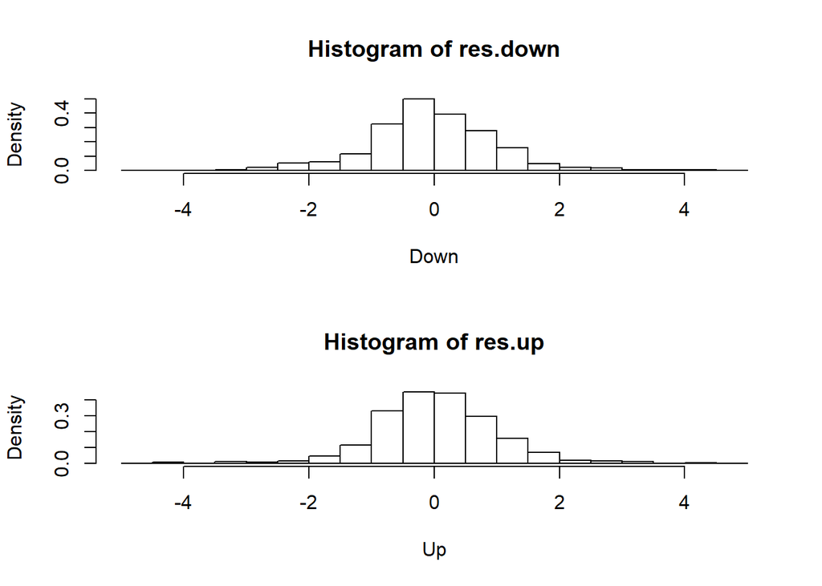

```r
up <- Direction[train]=="Up"
X.up <- c(Lag1[train][up], Lag2[train][up])
n <- length(X.up)/2
data.up <- matrix(X.up, n,2)

X.down <- c(Lag1[train][!up], Lag2[train][!up])
n <- length(X.down)/2
data.down <- matrix(X.down, n,2)

res.up <- data.up%*%lda.fit$scaling
res.down <- data.down%*%lda.fit$scaling

{par(mfrow=c(2,1))
hist(res.down, freq=F, xlab="Down", breaks = c(seq(-5, 5, 0.5)))
hist(res.up, freq=F, xlab="Up", breaks = c(seq(-5, 5, 0.5)))
}
```

The `predict()` function returns a list with three elements. The first element, `class`, contains LDA’s predictions about the movement of the market. The second element, `posterior`, is a matrix whose kth column contains the posterior probability that the corresponding observation belongs to the kth class, computed from (4.10). Finally, x contains the linear discriminants, described earlier.

```r
lda.pred <- predict(lda.fit, Smarket.2005)
names(lda.pred)
```

```
## [1] "class"     "posterior" "x"
```

As we observed in Section 4.5, the LDA and logistic regression predictions are almost identical.

```r
lda.class <- lda.pred$class
table(lda.class, Direction.2005)
```

```
##          Direction.2005
## lda.class Down  Up
##      Down   35  35
##      Up     76 106
```

```r
mean(lda.class==Direction.2005)
```

```
## [1] 0.5595238
```

Applying a 50% threshold to the posterior probabilities allows us to recreate (воссоздать) the predictions contained in lda.pred$class.

```r
sum(lda.pred$posterior[,1]>=0.5)
```

```
## [1] 70
```

```r
sum(lda.pred$posterior[,1]<0.5)
```

```
## [1] 182
```

Notice that the posterior probability output by the model corresponds to the probability that the market will *decrease*:
$$P(Y=\text{Down} \: | \: X=x ) \ge 0.5.$$

```r
lda.pred$posterior[1:18, 1]
```

```
##       999      1000      1001      1002      1003      1004      1005
## 0.4901792 0.4792185 0.4668185 0.4740011 0.4927877 0.4938562 0.4951016
##      1006      1007      1008      1009      1010      1011      1012
## 0.4872861 0.4907013 0.4844026 0.4906963 0.5119988 0.4895152 0.4706761
##      1013      1014      1015      1016
## 0.4744593 0.4799583 0.4935775 0.5030894
```

```r
lda.pred$class[1:18]
```

```
##  [1] Up   Up   Up   Up   Up   Up   Up   Up   Up   Up   Up   Down Up   Up
## [15] Up   Up   Up   Down
## Levels: Down Up
```

If we wanted to use a posterior probability threshold other than 50% in order to make predictions, then we could easily do so. For instance, suppose that we wish to predict a market decrease only if we are very certain that the market will indeed decrease on that day—say, if the posterior probability is at least 90%.

```r
sum(lda.pred$posterior[,1]>0.9)
```

```
## [1] 0
```

No days in 2005 meet that threshold! In fact, the greatest posterior probability of decrease in all of 2005 was 52.02%.

### 4.6.4 Quadratic Discriminant Analysis

We will now fit a QDA model to the Smarket data. QDA is implemented in R using the qda() function, which is also part of the MASS library. The syntax is identical to that of lda().

```r
qda.fit <- qda(Direction ~ Lag1+Lag2, data=Smarket, subset=train)
qda.fit
```

```
## Call:
## qda(Direction ~ Lag1 + Lag2, data = Smarket, subset = train)
##
## Prior probabilities of groups:
##     Down       Up
## 0.491984 0.508016
##
## Group means:
##             Lag1        Lag2
## Down  0.04279022  0.03389409
## Up   -0.03954635 -0.03132544
```

The output contains the group means. But it does not contain the coefficients of the linear discriminants, because the QDA classifier involves a quadratic, rather than a linear, function of the predictors. The `predict()` function works in exactly the same fashion as for LDA.

```r
qda.class <- predict(qda.fit, Smarket.2005)$class
table(qda.class, Direction.2005)
```

```
##          Direction.2005
## qda.class Down  Up
##      Down   30  20
##      Up     81 121
```

```r
mean(qda.class==Direction.2005)
```

```
## [1] 0.5992063
```

Interestingly, the QDA predictions are accurate almost 60% of the time, even though the 2005 data was not used to fit the model. This level of accuracy is quite impressive for stock market data, which is known to be quite hard to model accurately. This suggests that the quadratic form assumed by QDA may capture the true relationship more accurately than the linear forms assumed by LDA and logistic regression. However, we recommend evaluating this method’s performance on a larger test set before betting that this approach will consistently beat the market!

### 4.6.5 K-Nearest Neighbors

We will now perform KNN using the `knn()` function, which is part of the class library. This function works rather differently from the other modelfitting functions that we have encountered thus far. Rather than a two-step approach in which we first fit the model and then we use the model to make predictions, `knn()` forms predictions using a single command. The function requires four inputs.

1. A matrix containing the predictors associated with the training data, labeled train.X below.
2. A matrix containing the predictors associated with the data for which we wish to make predictions, labeled test.X below.
3. A vector containing the class labels for the training observations, labeled train.Direction below.
4. A value for K, the number of nearest neighbors to be used by the classifier.

We use the `cbind()` function, short for column bind, to bind the `Lag1` and `Lag2` variables together into two matrices, one for the training set and the other for the test set.

```r
library(class)
train.X <- cbind(Lag1, Lag2)[train,]
test.X <- cbind(Lag1, Lag2)[!train,]
train.Direction <- Direction[train]
```

Now the `knn()` function can be used to predict the market’s movement for the dates in 2005. We set a random seed before we apply `knn()` because if several observations are tied as nearest neighbors, then R will randomly break the tie (потому что если несколько наблюдений связаны как ближайшие соседи, то R случайно разорвет связь). Therefore, a seed must be set in order to ensure reproducibility of results.

```r
set.seed(1)
knn.pred <- knn(train.X, test.X, train.Direction, k=1)
table(knn.pred, Direction.2005)
```

```
##         Direction.2005
## knn.pred Down Up
##     Down   43 58
##     Up     68 83
```

```r
(83+43)/252
```

```
## [1] 0.5
```

The results using K = 1 are not very good, since only 50% of the observations are correctly predicted. Of course, it may be that K = 1 results in an overly flexible fit to the data. Below, we repeat the analysis using K = 3.

```r
knn.pred <- knn(train.X, test.X, train.Direction, k=3)
table(knn.pred, Direction.2005)
```

```
##         Direction.2005
## knn.pred Down Up
##     Down   48 54
##     Up     63 87
```

```r
mean(knn.pred==Direction.2005)
```

```
## [1] 0.5357143
```

The results have improved slightly. But increasing K further turns out to provide no further improvements. It appears that for this data, QDA provides the best results of the methods that we have examined so far.

```r
detach(Smarket)
```

### 4.6.6 An Application to Caravan Insurance Data

Finally, we will apply the KNN approach to the Caravan data set, which is part of the ISLR library. This data set includes 85 predictors that measure demographic characteristics for 5,822 individuals. The response variable is Purchase, which indicates whether or not a given individual purchases a caravan insurance policy. In this data set, only 6% of people purchased caravan insurance.

```r
dim(Caravan)
```

```
## [1] 5822   86
```

```r
attach(Caravan)
summary(Purchase)
```

```
##   No  Yes
## 5474  348
```

```r
348/5822
```

```
## [1] 0.05977327
```

Because the KNN classifier predicts the class of a given test observation by identifying the observations that are nearest to it, the scale of the variables matters. Any variables that are on a large scale will have a much larger effect on the distance between the observations, and hence on the KNN classifier, than variables that are on a small scale. A good way to handle this problem is to standardize the data so that all standardize variables are given a mean of zero and a standard deviation of one. Then all variables will be on a comparable scale. The scale() function does just scale() this. In standardizing the data, we exclude column 86, because that is the qualitative Purchase variable.

```r
standardized.X <- scale(Caravan[,-86])
var(Caravan[,1])
```

```
## [1] 165.0378
```

```r
var(Caravan[,2])
```

```
## [1] 0.1647078
```

```r
var(standardized.X[,1])
```

```
## [1] 1
```

```r
var(standardized.X[,2])
```

```
## [1] 1
```

Now every column of standardized.X has a standard deviation of one and a mean of zero.

We now split the observations into a test set, containing the first 1,000 observations, and a training set, containing the remaining observations. We fit a KNN model on the training data using K = 1, and evaluate its performance on the test data.

```r
test <- 1:1000
train.X <- standardized.X[-test,]
test.X <- standardized.X[test,]
train.Y <- Purchase[-test]
test.Y <- Purchase[test]
set.seed(1)
knn.pred <- knn(train.X, test.X, train.Y, k=1)
mean(test.Y!=knn.pred)
```

```
## [1] 0.118
```

```r
mean(test.Y!="No")
```

```
## [1] 0.059
```

The KNN error rate on the 1,000 test observations is just under 12%. At first glance, this may appear to be fairly good. Однако, всего 6% клиентов купили страховку, мы могли бы снизить частоту ошибок до 6%, всегда предсказывая No независимо от значений предикторов!

Предположим, что существует некоторая нетривиальная стоимость попытки продать страховку данному лицу. Suppose that there is some non-trivial cost to trying to sell insurance to a given individual. For instance, perhaps a salesperson must visit each potential customer. If the company tries to sell insurance to a random selection of customers, then the success rate will be only 6%, which may be far too low given the costs involved. Instead, the company would like to try to sell insurance only to customers who are likely to buy it. So the overall error rate is not of interest. Instead, the fraction of individuals that are correctly predicted to buy insurance is of interest.

Оказывается, KNN с K = 1 делает гораздо лучше, чем случайное угадывание среди клиентов, которые, по прогнозам, купят страховку. Из 77 таких клиентов 9, или 11,7%, фактически покупают страховку. Это вдвое больше, чем можно было бы получить от случайного угадывания.

```r
table(knn.pred, test.Y)
```

```
##         test.Y
## knn.pred  No Yes
##      No  873  50
##      Yes  68   9
```

```r
9/(68+9)
```

```
## [1] 0.1168831
```

Using K = 3, the success rate increases to 19 %, and with K = 5 the rate is 26.7%. This is over four times the rate that results from random guessing. It appears that KNN is finding some real patterns in a difficult data set!

```r
knn.pred <- knn(train.X, test.X, train.Y, k=3)
table(knn.pred, test.Y)
```

```
##         test.Y
## knn.pred  No Yes
##      No  920  54
##      Yes  21   5
```

```r
5/(21+5)
```

```
## [1] 0.1923077
```

```r
knn.pred <- knn(train.X, test.X, train.Y, k=5)
table(knn.pred, test.Y)
```

```
##         test.Y
## knn.pred  No Yes
##      No  930  55
##      Yes  11   4
```

```r
4/(11+4)
```

```
## [1] 0.2666667
```

As a comparison, we can also fit a logistic regression model to the data. If we use 0.5 as the predicted probability cut-off for the classifier, then we have a problem: only seven of the test observations are predicted to purchase insurance. Even worse, we are wrong about all of these! However, we are not required to use a cut-off of 0.5. If we instead predict a purchase any time the predicted probability of purchase exceeds 0.25, we get much better results: we predict that 33 people will purchase insurance, and we are correct for about 33% of these people. This is over five times better than random guessing!

```r
glm.fit <- glm(Purchase ~ ., data=Caravan, family=binomial, subset=-test)
glm.probs <- predict(glm.fit, Caravan[test,], type="response")
glm.pred <- rep("No", 1000)
glm.pred[glm.probs >0.5] = "Yes"
table(glm.pred, test.Y)
```

```
##         test.Y
## glm.pred  No Yes
##      No  934  59
##      Yes   7   0
```

```r
glm.pred <- rep("No", 1000)
glm.pred[glm.probs > 0.25] = "Yes"
table(glm.pred, test.Y)
```

```
##         test.Y
## glm.pred  No Yes
##      No  919  48
##      Yes  22  11
```

```r
11/(22+11)
```

```
## [1] 0.3333333
```

## Упражнения по ходу чтения главы

```r
data("Default")
head(Default)
```

```
##   default student   balance    income
## 1      No      No  729.5265 44361.625
## 2      No     Yes  817.1804 12106.135
## 3      No      No 1073.5492 31767.139
## 4      No      No  529.2506 35704.494
## 5      No      No  785.6559 38463.496
## 6      No     Yes  919.5885  7491.559
```

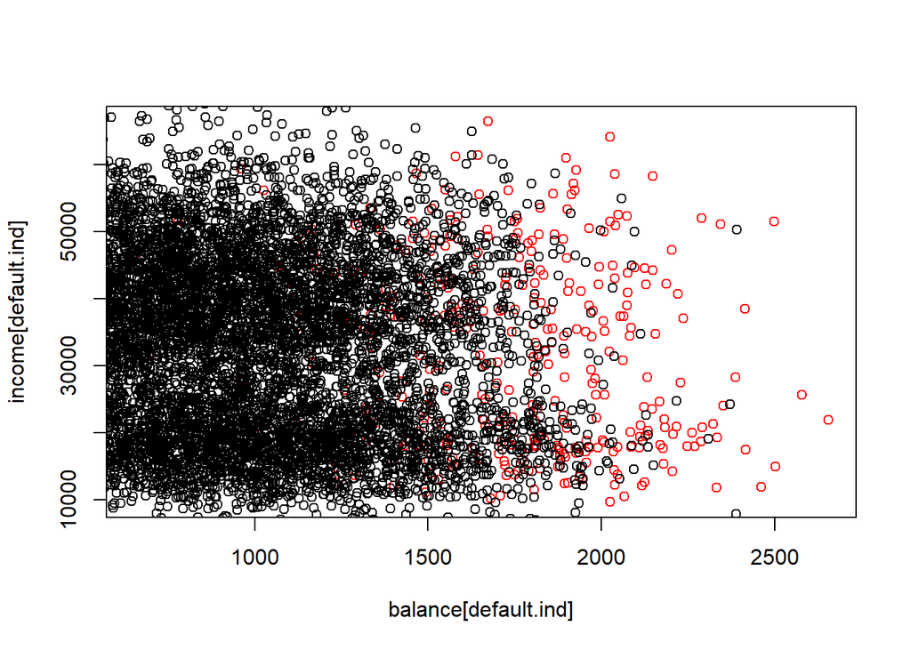

```
## integer(0)
```

```r
attach(Default)

default.ind <- default == "Yes"



plot(balance[default.ind], income[default.ind], col=2)+
  points(balance[!default.ind], income[!default.ind], col=1)
```

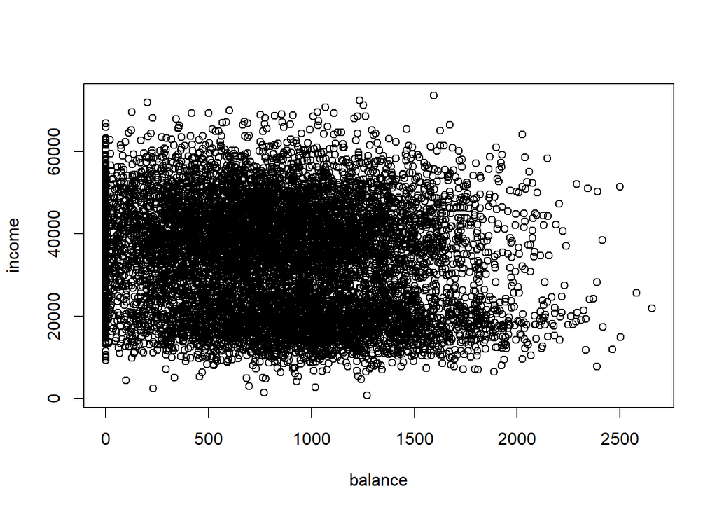

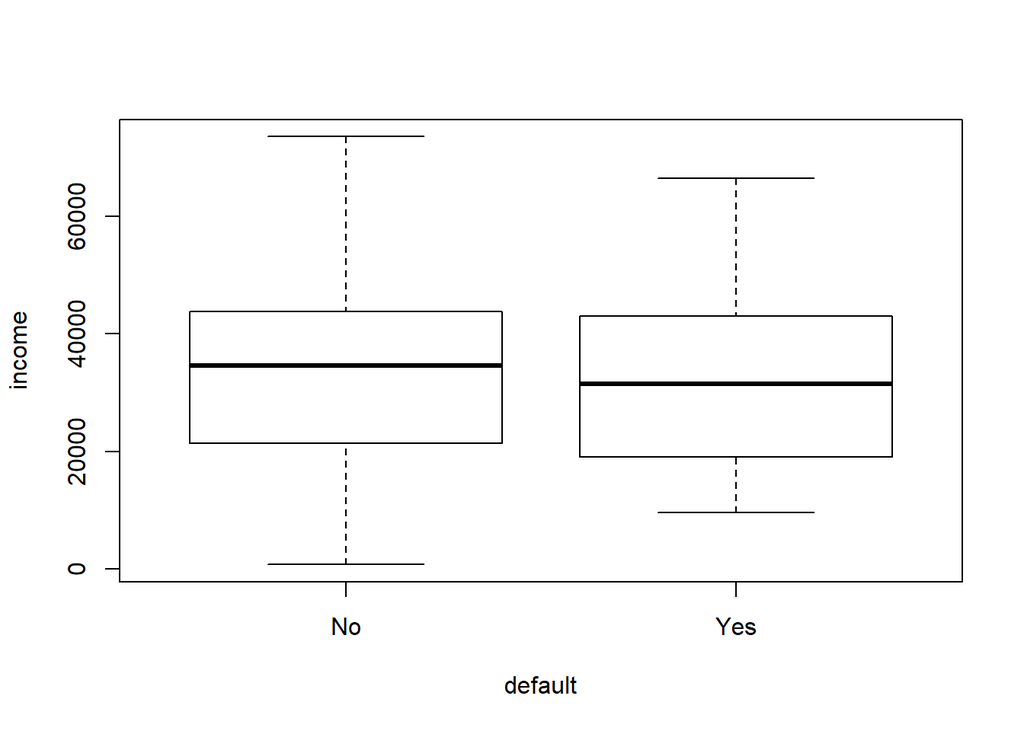

```r
plot(income ~ balance + default)
```

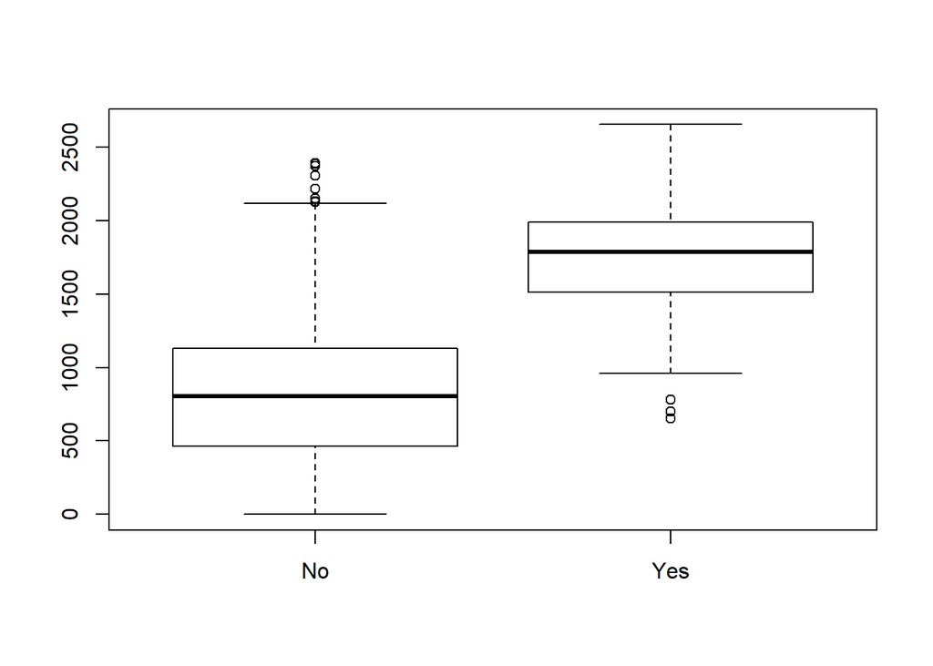

```r
plot(default, balance)
```

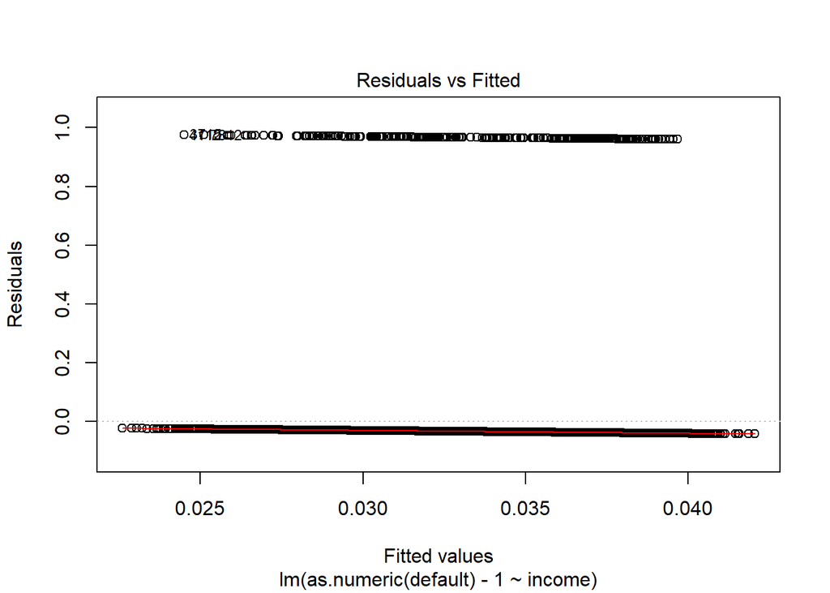

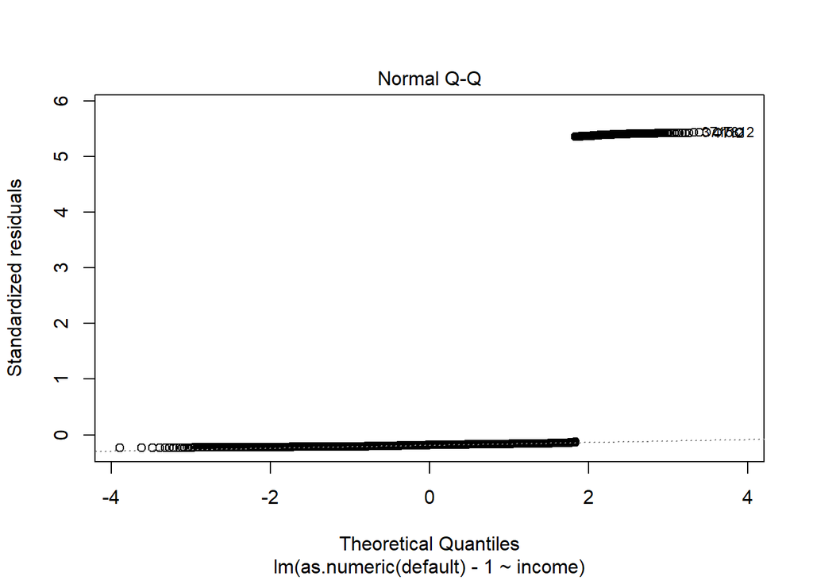

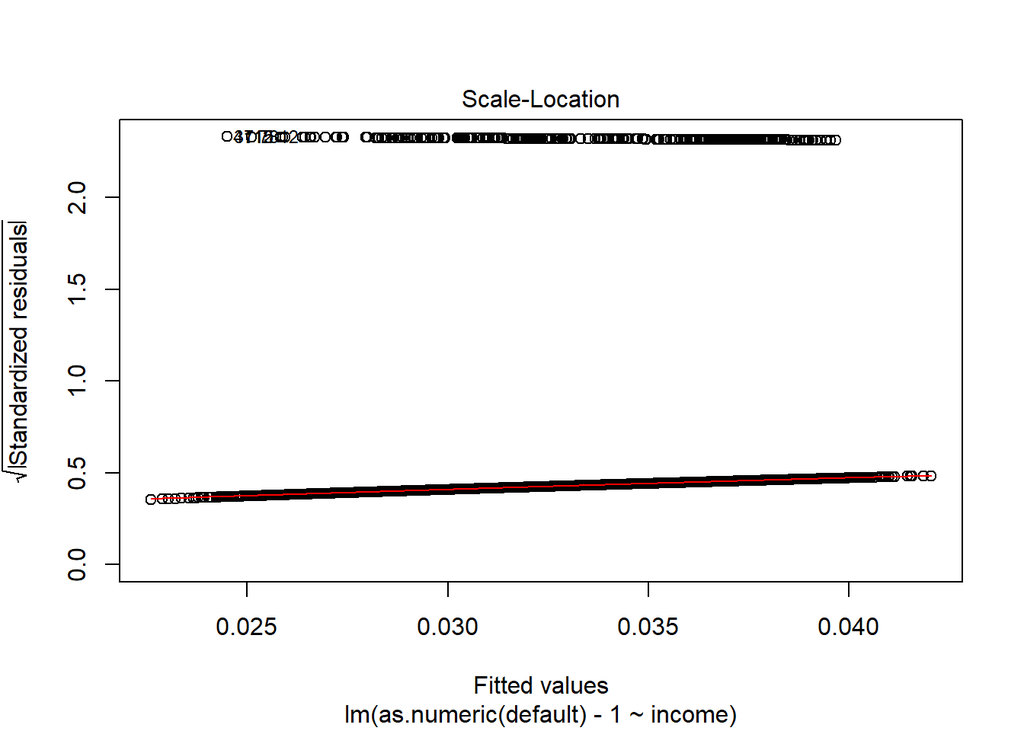

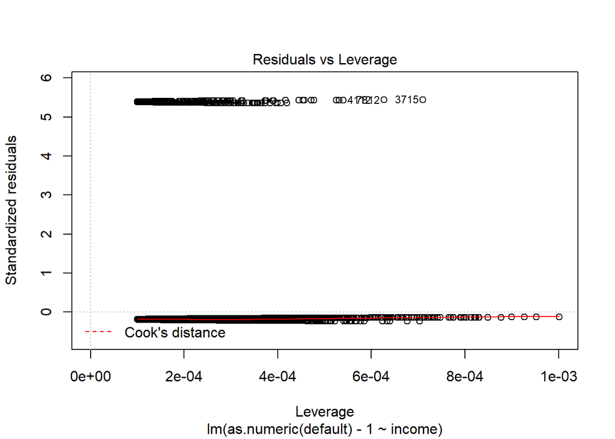

```r
lm.fit <- lm(as.numeric(default)-1 ~ income, Default)

plot(lm.fit)
```

```r
summary(lm.fit)
```

```
##
## Call:
## lm(formula = as.numeric(default) - 1 ~ income, data = Default)
##
## Residuals:
##      Min       1Q   Median       3Q      Max
## -0.04205 -0.03644 -0.03283 -0.03029  0.97551
##
## Coefficients:
##               Estimate Std. Error t value Pr(>|t|)
## (Intercept)  4.226e-02  4.853e-03   8.709   <2e-16 ***
## income      -2.673e-07  1.345e-07  -1.987   0.0469 *
## ---
## Signif. codes:  0 '***' 0.001 '**' 0.01 '*' 0.05 '.' 0.1 ' ' 1
##
## Residual standard error: 0.1794 on 9998 degrees of freedom
## Multiple R-squared:  0.0003949,  Adjusted R-squared:  0.0002949
## F-statistic:  3.95 on 1 and 9998 DF,  p-value: 0.04691
```

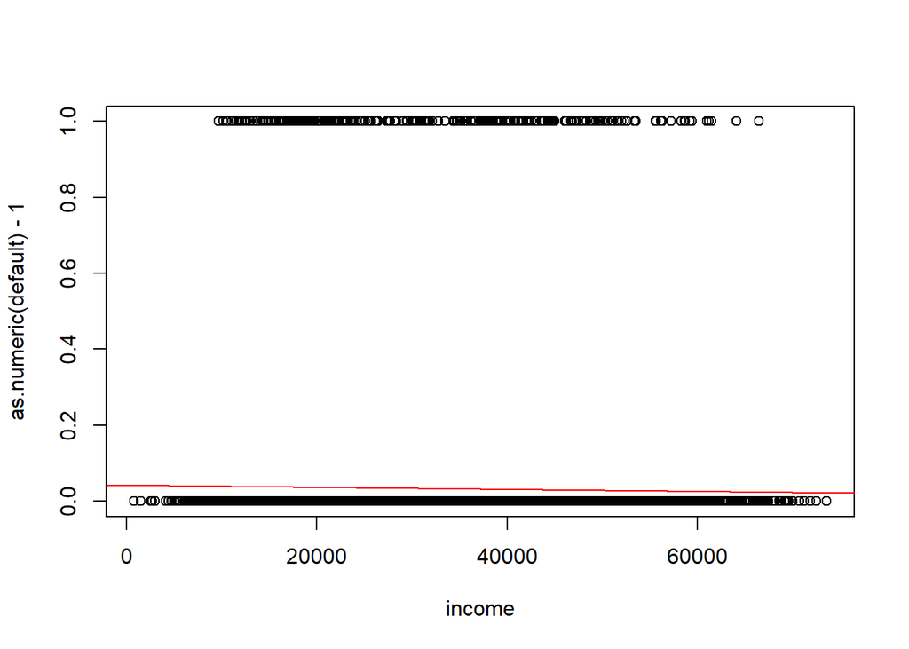

```
## integer(0)
```

```r
plot(income, as.numeric(default)-1 )+
  abline(lm.fit, col=2)
```

#### Рисуем график на стр. 137 (Figure 4.3)

```r
predict(lm.fit, data.frame(income = 50000))
```

```
##          1
## 0.02889334
```

```r
glm.fit=glm(default ~ balance + income + student, data=Default ,family =binomial )
summary(glm.fit)
```

```
##
## Call:
## glm(formula = default ~ balance + income + student, family = binomial,
##     data = Default)
##
## Deviance Residuals:
##     Min       1Q   Median       3Q      Max
## -2.4691  -0.1418  -0.0557  -0.0203   3.7383
##
## Coefficients:
##               Estimate Std. Error z value Pr(>|z|)
## (Intercept) -1.087e+01  4.923e-01 -22.080  < 2e-16 ***
## balance      5.737e-03  2.319e-04  24.738  < 2e-16 ***
## income       3.033e-06  8.203e-06   0.370  0.71152
## studentYes  -6.468e-01  2.363e-01  -2.738  0.00619 **
## ---
## Signif. codes:  0 '***' 0.001 '**' 0.01 '*' 0.05 '.' 0.1 ' ' 1
##
## (Dispersion parameter for binomial family taken to be 1)
##
##     Null deviance: 2920.6  on 9999  degrees of freedom
## Residual deviance: 1571.5  on 9996  degrees of freedom
## AIC: 1579.5
##
## Number of Fisher Scoring iterations: 8
```

```r
ind <- Default[ , "student"] == "Yes"

default.rate.students <- fitted(glm.fit)[ind]
default.rate.nonstudents <- fitted(glm.fit)[!ind]

length(default.rate.students)
```

```
## [1] 2944
```

```r
length(default.rate.nonstudents)
```

```
## [1] 7056
```

```r
m1 <- mean(fitted(glm.fit)[ind])
m2 <- mean(fitted(glm.fit)[!ind])

cor(as.numeric(student), balance)
```

```
## [1] 0.2035777
```

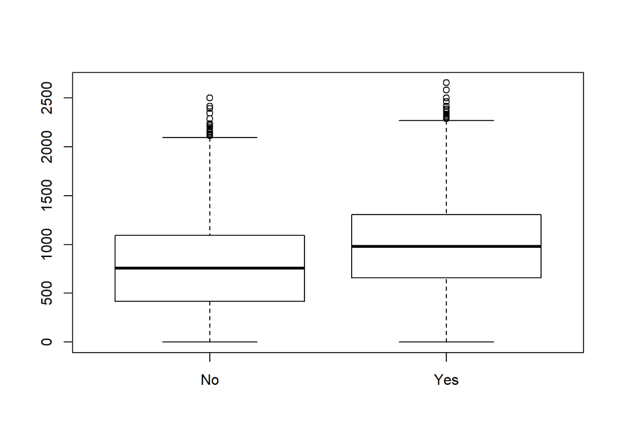

```r
plot(student, balance)
```

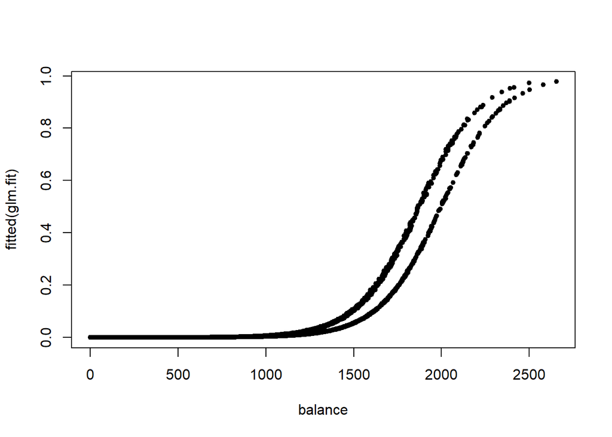

```r
plot(balance, fitted(glm.fit), pch=20)
```

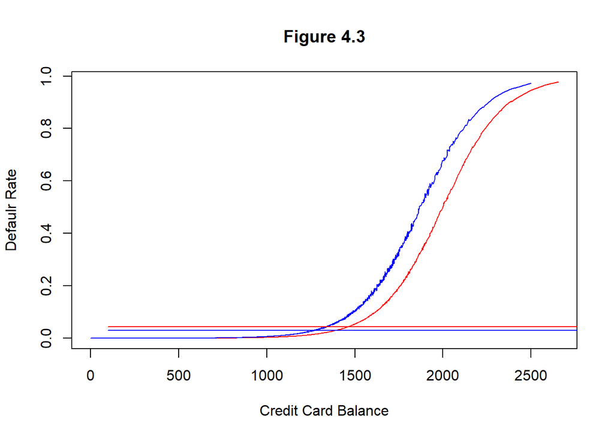

```
## integer(0)
```

```r
plot(sort(balance[ind]), fitted(glm.fit)[ind][order(balance[ind])], col = 2, type="l", xlab = "Credit Card Balance", ylab="Defaulr Rate", main = "Figure 4.3")+
  lines(sort(balance[!ind]), fitted(glm.fit)[!ind][order(balance[!ind])], col = 4)+
  lines(c(100, 5000), c(m1, m1), col=2)+
  lines(c(100, 5000), c(m2, m2), col=4)
```

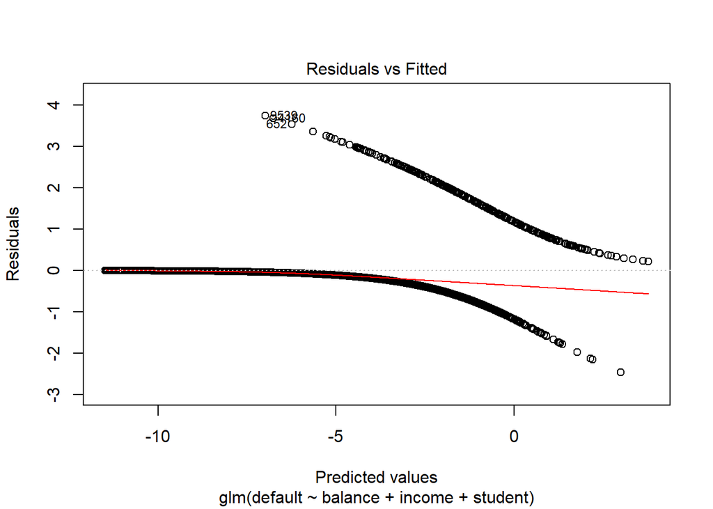

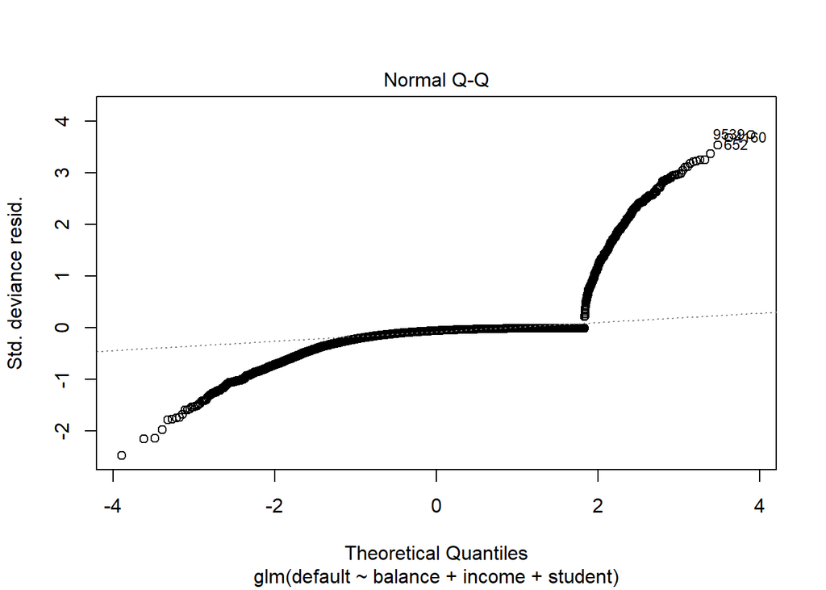

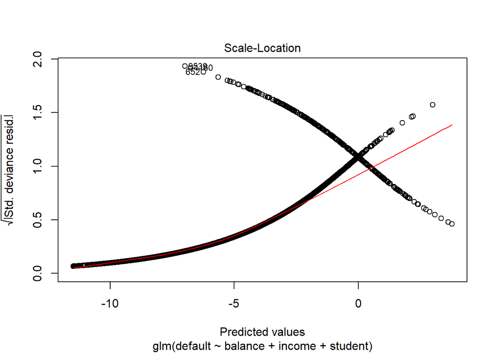

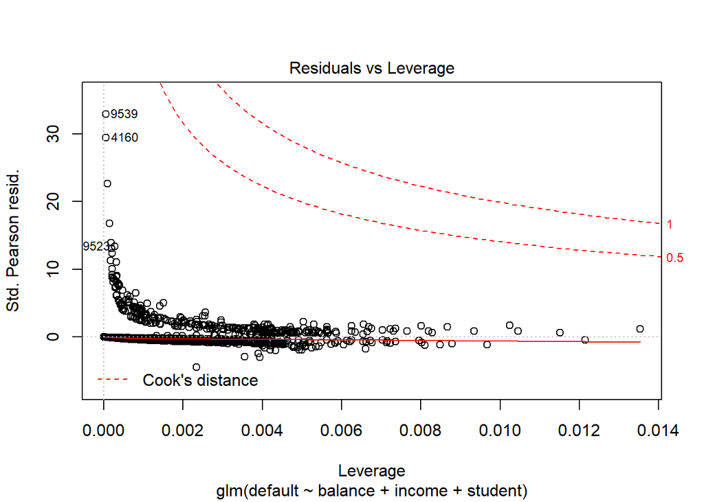

```r
plot(glm.fit)
```

#### Может ли граница решения QDA быть эллипсом?

Моедлируем нечто напоминающее сценарий 5 на стр.153.

Scenario 5: Within each class, the observations were generated from a normal distribution with uncorrelated predictors. However, the responses were sampled from the logistic function using $X^2_1, \: X^2_2$, and $X_1 \times X_2$ as predictors. Consequently, there is a quadratic decision boundary. The center panel of Figure 4.11 indicates that QDA once again performed best, followed closely by KNN-CV. The linear methods had poor performance.

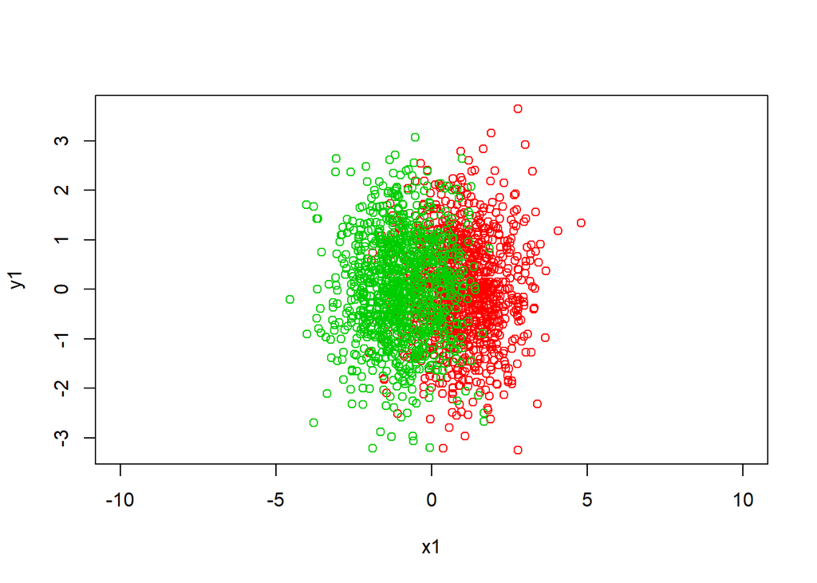

```
## integer(0)
```

```r
# simulation of observations from a normal distribution N(m1, sigma) and N(m2, sigma), where sigma = [1, 0; 0, 1], m1 = [-1,0] and m2 = [1,0].
N <- 1000
x1 <- rnorm(N, mean=1)
y1 <- rnorm(N, mean=0)

x2 <- rnorm(N, mean=-1)
y2 <- rnorm(N, mean=0)

# plot results of simulation
plot(x1,y1, col=2, xlim=c(-10,10))+
  points(x2,y2, col=3)
```

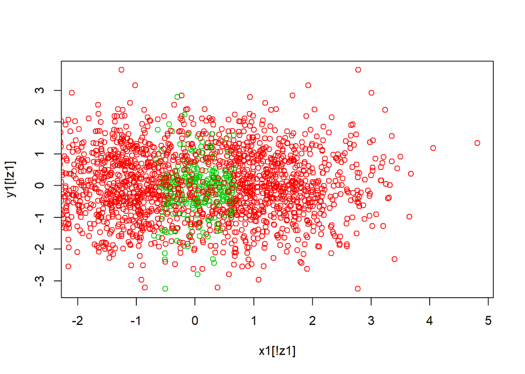

```
## integer(0)
```

```r
# classificator
logregclass <- function(x,y){
  #return(exp((x^2+y^2))/(1+exp((x^2+y^2))) > 0.8)
  return(x^2+y^2<0.5)
}

z1 <- logregclass(x1,y1)
z2 <- logregclass(x2,y2)

plot(x1[!z1], y1[!z1], col=2)+
  points(x1[z1], y1[z1], col=3)+
  points(x2[z2], y1[z2], col=3)+
  points(x2[!z2], y1[!z2], col=2)
```

Now apply QDA approach to this data.

```r
library("rrcov")
```

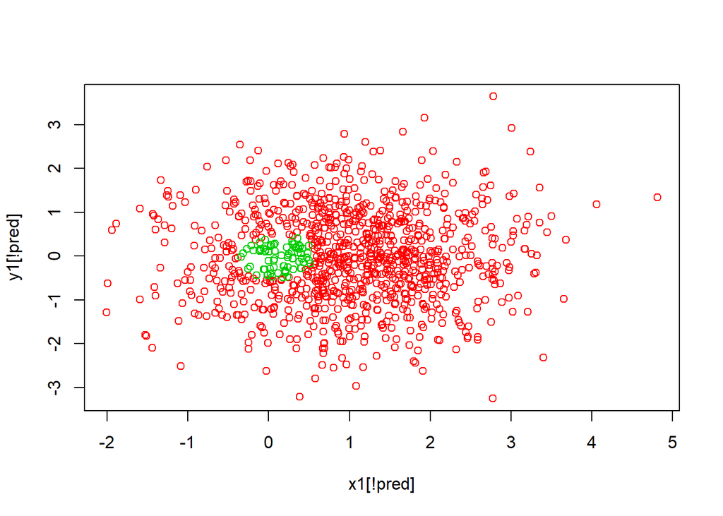

```
## integer(0)
```

```r
xx <- c(x1,x2)
yy <- c(y1,y2)
zz <- c(z1,z2)

train <- data.frame(class=zz, x=xx, y=yy)
qda.fit <- QdaCov(class ~ x+y, train)
obj.pred <- predict(qda.fit, data.frame(x=xx, y=yy))

pred <- as.logical(obj.pred@classification)

plot(x1[!pred], y1[!pred], col=2)+
  points(x1[pred], y1[pred], col=3)
```

Look at QDA decision boundary. It`s eppipse!

```r
library(pracma) # for mesh
```

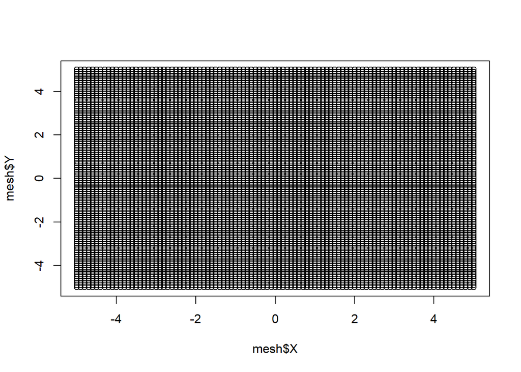

```r
x <- seq(-5, 5, 0.1)
mesh <- meshgrid(x, y = x)

plot(mesh$X, mesh$Y)
```

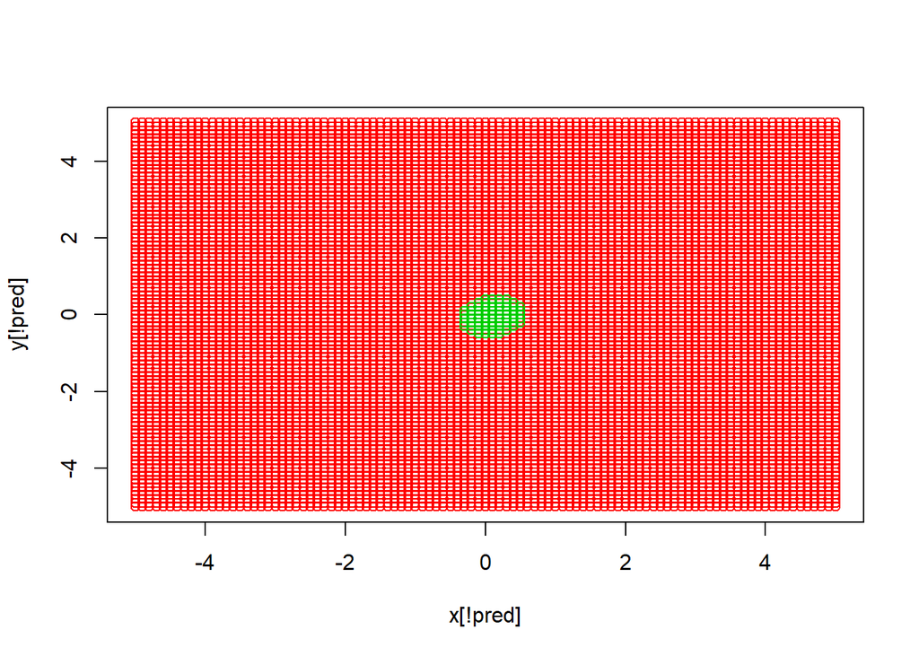

```
## integer(0)
```

```r
x <- c(mesh$X)
y <- c(mesh$Y)

obj.pred <- predict(qda.fit, data.frame(x=x, y=y))

pred <- as.logical(obj.pred@classification)

plot(x[!pred], y[!pred], col=2)+
  points(x[pred], y[pred], col=3)
```